# Homework Assignment 1

Jiusheng Chen (Simon)

### HW 1 - Getting Started with `R` -

**Due : Monday 3/20/17 6 PM EST**

- Upload a `.html` file with your solutions to our Ember page.
- Use `RMarkdown` to report back your solutions. You can easily use the `knit` function to export your file (with `R` code and text) to a `.html` file for your homework submission.
- Add as many comments to your code (recall that using the symbol `#` in the `R` chunk of code allows you to add extra comments to your code), and make sure to add the appropriate text explaining what you are doing in every problem

### Exercise 1

`R` comes with many functions that you can use to do sophisticated tasks like random sampling. For example, you can round a number with the `round()` function, or calculate its factorial with the `factorial()` function. Using a function is pretty simple. Just write the name of the function and then the data you want the function to operate on in parentheses.

- Find `round(3.1415)`, `factorial(12)`, `mean(1:17)`.
- You can create an object named `die` that contains the numbers one through six:

```r
# Create a vector with numbers from 1 to 6
die <- 1:6
die
```

```
## [1] 1 2 3 4 5 6
```

You can simulate a roll of the die with `R`s `sample()` function. `sample()` takes two arguments: a vector named `x` and a number named `size`.

- Try `sample(x = die, size = 1)`. Is there any difference if you type `sample(die, size = 1)` ?
- What does `args(round)` returns? Round 3.14159265 to 4 decimal places.

#### Solution to Exercise 1

```r
# Insert your solutions to Exercise 1 here
round(3.1415)
```

```
## [1] 3
```

```r
factorial(12)
```

```
## [1] 479001600
```

```r
mean(1:17)
```

```
## [1] 9
```

```r
sample(x = die, size = 1)
```

```
## [1] 1
```

```r
sample(die, size = 1)
```

```
## [1] 2
```

### Exercise 2

Use `R` as a calculator to compute the following values:

1. $27 (38 -17)$
2. $ln(14^7)$
3. $\sqrt\frac{436}{12}$

#### Solution to Exercise 2

```r
# Insert your solutions to Exercise 2 here
27 * (38 - 17)
```

```
## [1] 567
```

```r
log10(14^7)
```

```
## [1] 8.022896
```

```r
sqrt(436/12)
```

```
## [1] 6.027714
```

### Exercise 3

Create the following vectors in `R`:

$a = (5, 10, 15, 20, ..., 160)$

$b = (87, 86, 85, ..., 56)$

Multiply these vectors and call the result `d`. Select subsets of `d` to identify the following.

- What are the 19th, 20th, and 21st elements of `d`?
- What are all of the elements of `d` which are less than 2000?
- How many elements of `d` are greater than 6000?

#### Solution to Exercise 3

```r
# Insert your solutions to Exercise 3 here
a <- seq(5, 160, by = 5)
a
```

```
##  [1]   5  10  15  20  25  30  35  40  45  50  55  60  65  70  75  80  85
## [18]  90  95 100 105 110 115 120 125 130 135 140 145 150 155 160
```

```r
b <- seq(87, 56, by = -1)
b
```

```
##  [1] 87 86 85 84 83 82 81 80 79 78 77 76 75 74 73 72 71 70 69 68 67 66 65
## [24] 64 63 62 61 60 59 58 57 56
```

```r
d <- a * b
d
```

```
##  [1]  435  860 1275 1680 2075 2460 2835 3200 3555 3900 4235 4560 4875 5180
## [15] 5475 5760 6035 6300 6555 6800 7035 7260 7475 7680 7875 8060 8235 8400
## [29] 8555 8700 8835 8960
```

```r
e <- d[c(19, 20, 21)]
e
```

```
## [1] 6555 6800 7035
```

```r
f <- d[c(d < 2000)]
f
```

```
## [1]  435  860 1275 1680
```

```r
g <- d[c(d > 6000)]
length(g)
```

```
## [1] 16
```

### Exercise 4

Start with this vector of `nouns`.

```r
nouns <- c("apple", "flower", "insect", "lettuce", "knife", "dog",
    "cloud", "person", "cabinet", "flower")
nouns
```

```
##  [1] "apple"   "flower"  "insect"  "lettuce" "knife"   "dog"     "cloud"
##  [8] "person"  "cabinet" "flower"
```

- use the `length()` function to display the number of elements in `nouns`.
- use indexing to create a new vector consisting of the first 4 elements of `nouns`.
- use indexing to create a new vector consisting of only the last 8 elements of `nouns`.
- use indexing to create a new vector of the 1st, 3rd through 6th, and 10th elements of `nouns` (the length of the resulting vector should be 6)
- create a new vector with the elements of `nouns` in reverse order.

#### Solution to Exercise 4

```r
# Insert your solutions to Exercise 4 here
length(nouns)
```

```
## [1] 10
```

```r
a <- nouns[1:4]
a
```

```
## [1] "apple"   "flower"  "insect"  "lettuce"
```

```r
b <- nouns[3:10]
b
```

```
## [1] "insect"  "lettuce" "knife"   "dog"     "cloud"   "person"  "cabinet"
## [8] "flower"
```

```r
c <- nouns[c(1, 3:6, 10)]
c
```

```
## [1] "apple"   "insect"  "lettuce" "knife"   "dog"     "flower"
```

```r
d <- rev(nouns)
d
```

```
##  [1] "flower"  "cabinet" "person"  "cloud"   "dog"     "knife"   "lettuce"
##  [8] "insect"  "flower"  "apple"
```

### Exercise 5

Look up the usage of the command `seq` (you can use `?seq` or `help(seq)` to obtain help from within `R`) Now determine what the following commands achieve:

```r
# In your HW assignment solutions, you want to remove the
# eval = FALSE option to actually 'evaluate' this chunk of
# code
x = seq(from = 0, to = 4 * pi, length.out = 1000)
y = sin(x)
plot(x, y, type = "l", main = "graph of sin(x)")
```

What happens if you leave out `type="l"` of the plot command? What happens if you choose another number, say 5, for the parameter `length.out` and redefine `x`?

#### Solution to Exercise 5

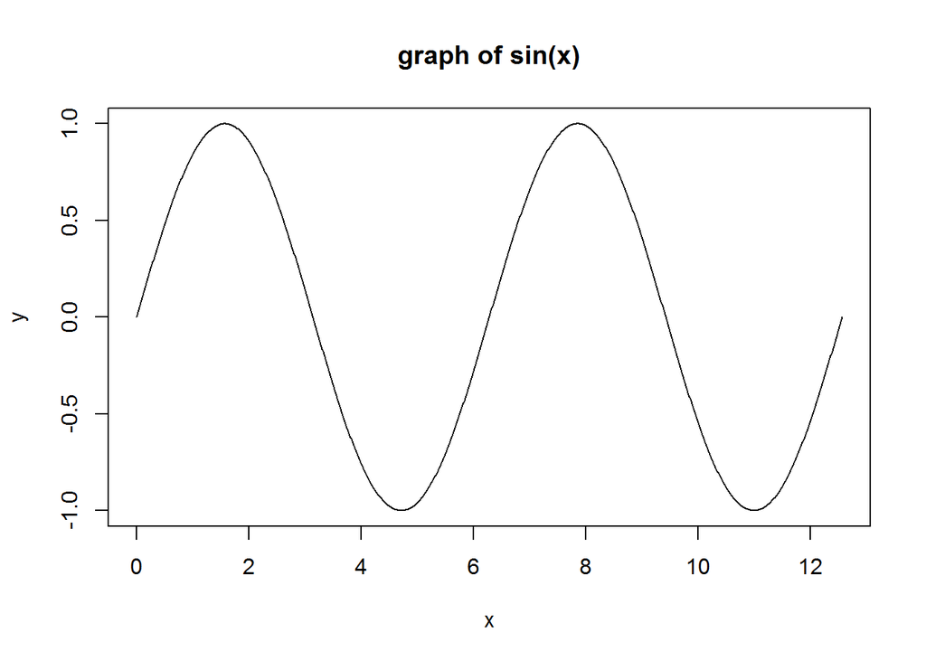

```r
# Insert your solutions to Exercise 5 here

x = seq(from = 0, to = 4 * pi, length.out = 1000)
y = sin(x)
plot(x, y, type = "l", main = "graph of sin(x)")
```

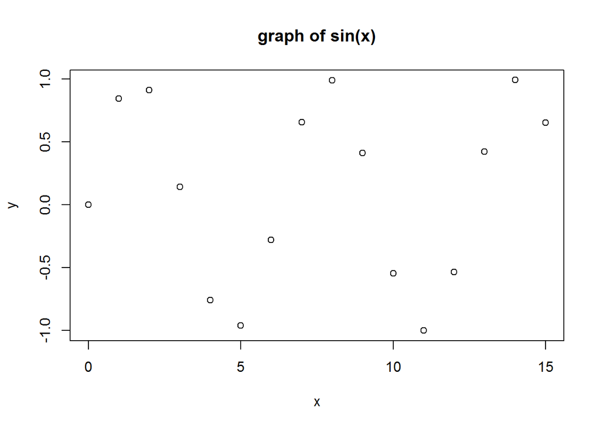

```r
x = seq(from = 0, to = 5 * pi, x = 1000)
y = sin(x)
plot(x, y, main = "graph of sin(x)")
```